# t_distribution

Xuening

4/13/2020

## t-statistic as a next best alternative to z-statistic

$Z=\frac{\bar{X}-\mu}{\sigma/\sqrt{n}}$ observes normal distribution. However, in reality, we often don’t know $\sigma$, the population standard deviation.

What if we use sample standard distribution as an approximation to $\sigma$? Will the distribution of $t=\frac{\bar{X}-\mu}{s/\sqrt{n}}$ change? Notice, the denominator of sample variance and standard deviation is $n-1$ and the denominator of population variance nad population standard deviation is $n$. Luckily the R functions `var()` and `sd()` uses denominator $n-1$.

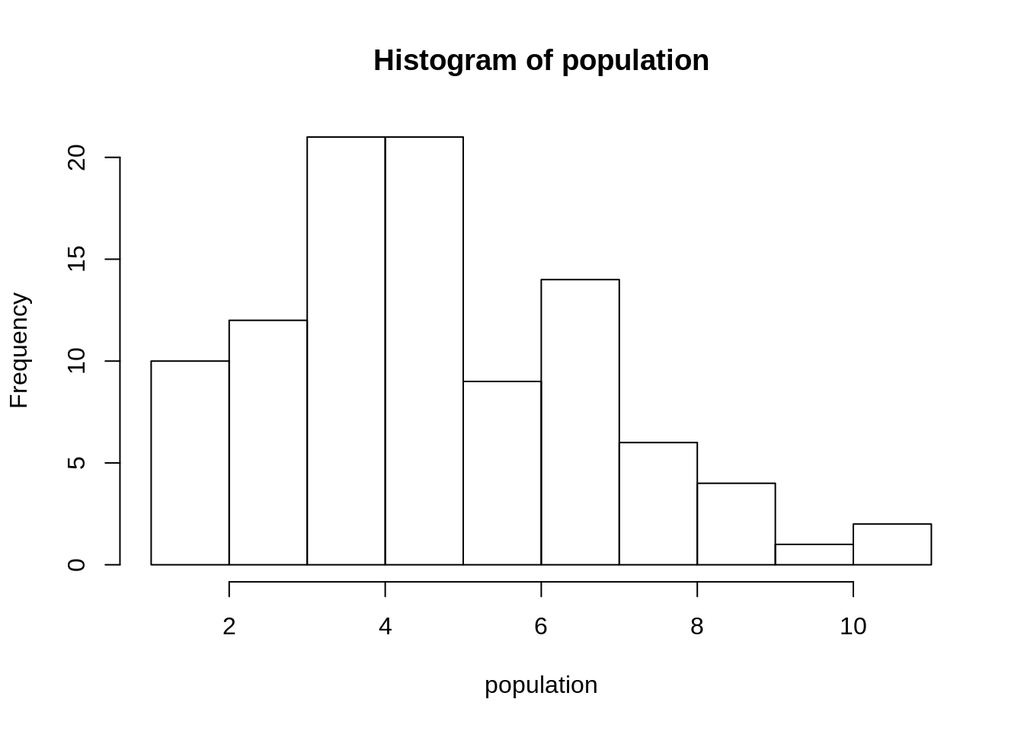

```r
population <- rpois(100,5) # uniform distribution with min=0 and max=1
hist(population)
```

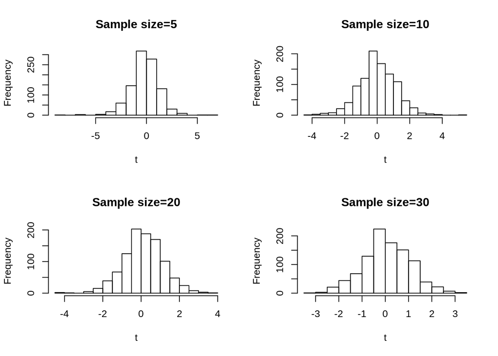

```r
sizes <- c(5,10,20,30)
par(mfrow=c(2,2))
for (size in sizes){
        samples <- replicate(1000,sample(population,size,replace=T))
        t <- apply(samples,2,function(this_col){
                (mean(this_col)-5)*sqrt(size)/sd(this_col)
        })
        hist(t,main=paste0("Sample size=",size),breaks = 20)
}
```

We can see that when sample size is small, the frequency of extreme values seems higher than that when sample size is large. This is because we have a random variable as the denominator of t. When the sample standard deviation $s$ happen to be very small, boom, the $|t|$ can be very large.

Let’s use quantiles to see how the distribution of $t=\frac{\bar{X}-\mu}{s/\sqrt{n}}$ compares to normal distribution.

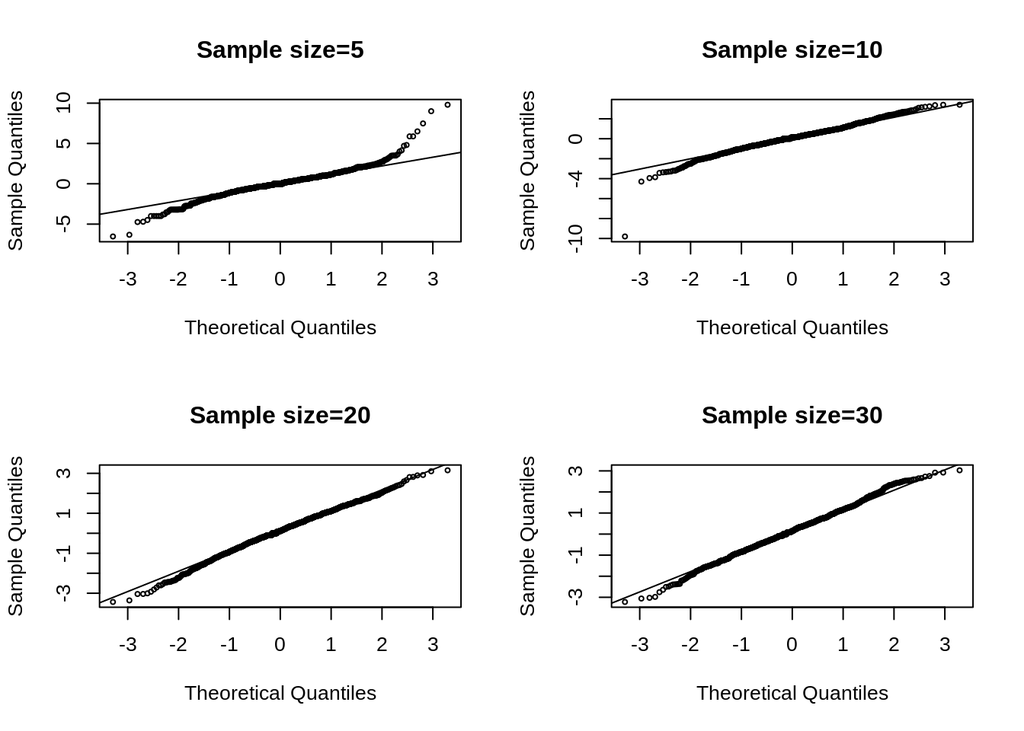

```r
#using quantiles to compare with normal distribution
par(mfrow=c(2,2))
for (size in sizes){
        samples <- replicate(1000,sample(population,size,replace=T))
        t <- apply(samples,2,function(this_col){
                (mean(this_col)-5)*sqrt(size)/sd(this_col)
        })
        qqnorm(t,main=paste0("Sample size=",size),cex=0.5)
        qqline(t)
}
```

This shows the relationship between t distribution and normal distribution: as sample size gets larger, t distribution become increasingly similar to normal distribution.

## Conclusion

Therefore, central limit theorem applies poorly when population variance is unknown. In reality, $t=\frac{\bar{X}-\mu}{s/\sqrt{n}}$ observes t-distribution, a bell-shaped curve with both tails thicker than normal distribution.